# Reproducing Crossa et al. (2011)

Muhammad Yaseen

2026-11-09

# 1 Abstract

Crossa et al. (2011) fitted the Bayesian AMMI model with two bilinear terms to the maize trial `Maiz`. They ran two chains of 35000 iterations, discarded a burn-in of 5000 and thinned by 2. This vignette repeats that run and compares the posterior summaries with their Tables 1 and B1. The overall mean, the error variance, the main effects, the singular values and the scores of the first term agree within Monte Carlo error. The second scores differ, for a reason the paper does not discuss: the sign of a weak term.

# 2 The run of the paper

```r
fit <-
  bayes_ammi(
      .data   = Maiz
    , .y      = y
    , .gen    = entry
    , .env    = site
    , .rep    = rep
    , .nIter  = 30000
    , .k      = 2
    , .burnin = 5000
    , .thin   = 2
    , .chains = 2
    , .priors = bam_priors(
          mu_mean     = 0
        , mu_var      = 1e+8
        , tau_mean    = 0
        , tau_var     = 1e+8
        , delta_mean  = 0
        , delta_var   = 1e+8
        , lambda_mean = 0
        , lambda_var  = 1e+8
        , nu          = 1
        , s2          = NULL
        )
    , .level  = 0.95
    , .seed   = 2011
    , .align  = TRUE
    , .model  = "AMMI"
    , .het    = FALSE
    , .waic   = TRUE
    )
fit$settings$seconds
```

```
[1] 8.09
```

# 3 Table 1

```r
pub <- utils::read.csv(file = system.file("extdata", "crossa2011.csv", package = "bayesammi"))
s <- fit$summary
t1 <- merge(x = pub[pub$table == "1", ], y = s[, list(parameter, mean, sd, lower, upper)],
            by = "parameter", suffixes = c(".paper", ".here"), sort = FALSE)
t1$dev_sd <- round(x = (t1$mean.here - t1$mean.paper) / t1$sd.paper, digits = 3)
num <- c("mean.paper", "mean.here", "sd.paper", "sd.here", "lower.paper", "lower.here", "upper.paper", "upper.here")
t1[num] <- lapply(X = t1[num], FUN = signif, digits = 5)
t1[, c("parameter", "mean.paper", "mean.here", "sd.paper", "sd.here", "dev_sd")]
```

```
   parameter mean.paper  mean.here sd.paper   sd.here dev_sd
1         mu    4858.00   4857.600    32.71    32.539 -0.012
2     sigma2  763600.00 762820.000 43580.00 43631.000 -0.018
3     tau[1]    -241.70   -241.050    91.78    92.348  0.007
4     tau[2]    -255.00   -254.360    91.97    91.456  0.007
5     tau[3]     -34.66    -35.607    91.75    91.862 -0.010
6     tau[4]     359.20    359.270    91.68    92.234  0.001
7     tau[5]     389.70    388.110    92.32    91.983 -0.017
8     tau[6]     472.50    471.850    91.47    92.025 -0.007
9     tau[7]    -186.00   -185.970    92.19    92.082  0.000
10    tau[8]    -574.90   -574.570    91.69    91.876  0.004
11    tau[9]      70.95     72.330    91.90    91.695  0.015
12  delta[1]   -1245.00  -1244.600   141.80   142.300  0.003
13  delta[2]    -647.30   -649.780   141.50   142.460 -0.018
14  delta[3]     246.60    246.630   141.60   141.440  0.000
```

[output cut: 19 more lines]

```r
t1[, c("parameter", "lower.paper", "lower.here", "upper.paper", "upper.here")]
```

```
   parameter lower.paper lower.here upper.paper upper.here
1         mu   4792.9000   4793.000   4921.0000   4920.100
2     sigma2 680570.0000 677110.000 849750.0000 847100.000
3     tau[1]   -421.8000   -419.590    -61.8490    -56.881
4     tau[2]   -433.0500   -435.610    -72.3490    -78.355
5     tau[3]   -213.5800   -216.420    147.9200    144.300
6     tau[4]    180.6000    175.520    541.1600    535.570
7     tau[5]    206.3700    206.740    567.9200    566.120
8     tau[6]    296.9900    295.540    655.4900    654.760
9     tau[7]   -363.9800   -369.400     -3.5244     -9.515
10    tau[8]   -758.7400   -749.270   -401.0400   -392.460
11    tau[9]   -107.7900   -107.690    247.4000    252.980
12  delta[1]  -1518.8000  -1530.600   -963.8600   -974.240
13  delta[2]   -925.3100   -925.220   -373.4200   -363.950
14  delta[3]    -28.9430    -22.012    525.8100    529.360
```

[output cut: 19 more lines]

## 3.1 The error variance

```r
fit_s2 <-
  bayes_ammi(
      .data   = Maiz
    , .y      = y
    , .gen    = entry
    , .env    = site
    , .rep    = rep
    , .nIter  = 3000
    , .k      = 2
    , .burnin = 500
    , .thin   = 1
    , .chains = 1
    , .priors = bam_priors(
          mu_mean     = 0
        , mu_var      = 1e+8
        , tau_mean    = 0
        , tau_var     = 1e+8
        , delta_mean  = 0
        , delta_var   = 1e+8
        , lambda_mean = 0
        , lambda_var  = 1e+8
        , nu          = 1
        , s2          = 1e8
        )
    , .level  = 0.95
    , .seed   = 1
    , .align  = TRUE
    , .model  = "AMMI"
    , .het    = FALSE
    , .waic   = TRUE
    )
c(default = s[parameter == "sigma2", mean], s2_1e8 = fit_s2$summary[parameter == "sigma2", mean])
```

```
 default   s2_1e8
762815.3 922193.4
```

The package therefore defaults to the least-squares residual mean square as the scale, which reproduces Table 1.

# 4 Table B1: the first term

```r
b1 <-
  merge(
      x        = pub[pub$table == "B1" & grepl(pattern = ",1\\]$", x = pub$parameter), ]
    , y        = s[, list(parameter, mean, sd, lower, upper)]
    , by       = "parameter"
    , suffixes = c(".paper", ".here")
    , sort     = FALSE
    )
b1$dev_sd <- round(x = (b1$mean.here - b1$mean.paper) / b1$sd.paper, digits = 3)
b1[c("mean.here", "sd.here")] <- lapply(X = b1[c("mean.here", "sd.here")], FUN = round, digits = 4)
b1[, c("parameter", "mean.paper", "mean.here", "sd.paper", "sd.here", "dev_sd")]
```

```
     parameter mean.paper mean.here sd.paper sd.here dev_sd
1   gamma[1,1]    -0.2110   -0.2121   0.0751  0.0751 -0.015
2   gamma[2,1]     0.0169    0.0163   0.0757  0.0755 -0.008
3   gamma[3,1]    -0.2427   -0.2426   0.0752  0.0748  0.001
4   gamma[4,1]     0.1389    0.1389   0.0734  0.0741  0.000
5   gamma[5,1]     0.0811    0.0808   0.0754  0.0751 -0.005
6   gamma[6,1]    -0.0068   -0.0055   0.0766  0.0765  0.017
7   gamma[7,1]    -0.0763   -0.0765   0.0753  0.0761 -0.003
8   gamma[8,1]    -0.6353   -0.6340   0.0613  0.0614  0.021
9   gamma[9,1]     0.0359    0.0358   0.0752  0.0751 -0.002
10 gamma[10,1]    -0.2052   -0.2056   0.0729  0.0730 -0.005
11 gamma[11,1]     0.3673    0.3676   0.0690  0.0690  0.005
12 gamma[12,1]     0.1510    0.1516   0.0754  0.0762  0.008
13 gamma[13,1]     0.2358    0.2356   0.0761  0.0764 -0.003
14 gamma[14,1]    -0.0058   -0.0066   0.0743  0.0740 -0.011
15 gamma[15,1]     0.1950    0.1960   0.0755  0.0752  0.013
16 gamma[16,1]     0.0746    0.0747   0.0739  0.0740  0.002
17 gamma[17,1]    -0.0008   -0.0004   0.0783  0.0781  0.006
18 gamma[18,1]     0.2042    0.2040   0.0769  0.0769 -0.003
19 gamma[19,1]    -0.0826   -0.0836   0.0761  0.0770 -0.013
20 gamma[20,1]    -0.0343   -0.0343   0.0760  0.0761  0.001
21  alpha[1,1]    -0.3724   -0.3703   0.0742  0.0748  0.028
22  alpha[2,1]    -0.2416   -0.2407   0.0756  0.0759  0.012
23  alpha[3,1]    -0.1603   -0.1610   0.0753  0.0754 -0.009
24  alpha[4,1]     0.5016    0.5020   0.0647  0.0645  0.006
25  alpha[5,1]     0.2756    0.2759   0.0775  0.0773  0.003
26  alpha[6,1]     0.2649    0.2639   0.0727  0.0735 -0.013
27  alpha[7,1]    -0.1152   -0.1158   0.0827  0.0820 -0.007
28  alpha[8,1]    -0.4661   -0.4676   0.0776  0.0782 -0.019
29  alpha[9,1]     0.3135    0.3136   0.0741  0.0735  0.002
```

The largest absolute deviation is 0.028 posterior standard deviations.

# 5 Table B1: the second term

```r
b2 <-
  merge(
      x        = pub[pub$table == "B1" & grepl(pattern = ",2\\]$", x = pub$parameter), ]
    , y        = s[, list(parameter, mean, sd)]
    , by       = "parameter"
    , suffixes = c(".paper", ".here")
    , sort     = FALSE
    )
b2[c("mean.here", "sd.here")] <- lapply(X = b2[c("mean.here", "sd.here")], FUN = round, digits = 4)
b2[, c("parameter", "mean.paper", "mean.here", "sd.paper", "sd.here")]
```

```
     parameter mean.paper mean.here sd.paper sd.here
1   gamma[1,2]     0.0840   -0.1314   0.2205  0.1979
2   gamma[2,2]    -0.0562    0.0866   0.2060  0.1963
3   gamma[3,2]     0.0539   -0.0867   0.2187  0.2085
4   gamma[4,2]     0.0271   -0.0429   0.1869  0.1821
5   gamma[5,2]     0.0300   -0.0400   0.1952  0.1906
6   gamma[6,2]    -0.0621    0.0973   0.2177  0.2032
7   gamma[7,2]     0.0331   -0.0524   0.1974  0.1910
8   gamma[8,2]    -0.1302    0.2057   0.2395  0.1855
9   gamma[9,2]    -0.0173    0.0230   0.1919  0.1899
10 gamma[10,2]     0.0184   -0.0340   0.1827  0.1792
11 gamma[11,2]    -0.0189    0.0335   0.1773  0.1742
12 gamma[12,2]    -0.0967    0.1561   0.2279  0.1934
13 gamma[13,2]    -0.0762    0.1207   0.2350  0.2184
14 gamma[14,2]    -0.0074    0.0114   0.1795  0.1768
15 gamma[15,2]     0.0884   -0.1396   0.2229  0.1959
16 gamma[16,2]    -0.0014    0.0010   0.1822  0.1815
17 gamma[17,2]     0.1313   -0.2093   0.2619  0.2055
18 gamma[18,2]    -0.1026    0.1661   0.2524  0.2159
19 gamma[19,2]     0.0246   -0.0398   0.2145  0.2127
20 gamma[20,2]     0.0784   -0.1252   0.2167  0.1916
21  alpha[1,2]    -0.0841    0.1441   0.3087  0.2883
22  alpha[2,2]    -0.1145    0.2020   0.2964  0.2433
23  alpha[3,2]    -0.0568    0.0935   0.2620  0.2484
24  alpha[4,2]     0.0059   -0.0016   0.2222  0.2189
25  alpha[5,2]     0.1241   -0.2186   0.3260  0.2752
26  alpha[6,2]     0.0820   -0.1387   0.2619  0.2321
27  alpha[7,2]    -0.1333    0.2362   0.3656  0.3086
28  alpha[8,2]     0.2483   -0.4364   0.4262  0.2385
29  alpha[9,2]    -0.0716    0.1195   0.2805  0.2617
```

Here the means differ, mostly in sign, and the published means are smaller in absolute value. The second term is weak: the HPD interval of $\lambda_2$ reaches down to near zero, both in the paper (2.09) and here (13.07). A chain without sign alignment then moves between the two mirror images $(\va_2, \vg_2)$ and $(-\va_2, -\vg_2)$. Its posterior means are averages over both images and shrink towards zero:

```r
fit_free <-
  bayes_ammi(
      .data   = Maiz
    , .y      = y
    , .gen    = entry
    , .env    = site
    , .rep    = rep
    , .nIter  = 30000
    , .k      = 2
    , .burnin = 5000
    , .thin   = 2
    , .chains = 1
    , .priors = bam_priors(
          mu_mean     = 0
        , mu_var      = 1e+8
        , tau_mean    = 0
        , tau_var     = 1e+8
        , delta_mean  = 0
        , delta_var   = 1e+8
        , lambda_mean = 0
        , lambda_var  = 1e+8
        , nu          = 1
        , s2          = NULL
        )
    , .level  = 0.95
    , .seed   = 2011
    , .align  = FALSE
    , .model  = "AMMI"
    , .het    = FALSE
    , .waic   = TRUE
    )
d <- fit_free$draws[[1]][, "alpha[8,2]"]
c(share_positive = mean(d > 0), mean = mean(d), paper = pub$mean[pub$parameter == "alpha[8,2]"])
```

```
share_positive           mean          paper
    0.51626667     0.01630027     0.24830000
```

The published value, 0.2483, is smaller in absolute value than the aligned posterior mean, -0.436, and has the opposite sign. A chain that spends a share $q$ of its run in the image opposite to the least-squares orientation has a mean of about $(1 - 2q)$ times the aligned one. The published value corresponds to $q \approx$ 0.78: the published chain spent most of its run in the other image. The aligned summaries in this package describe one orientation of the term, and the scores of genotypes then keep their meaning relative to each other.

# 6 Figure 1: traces and histograms of the singular values

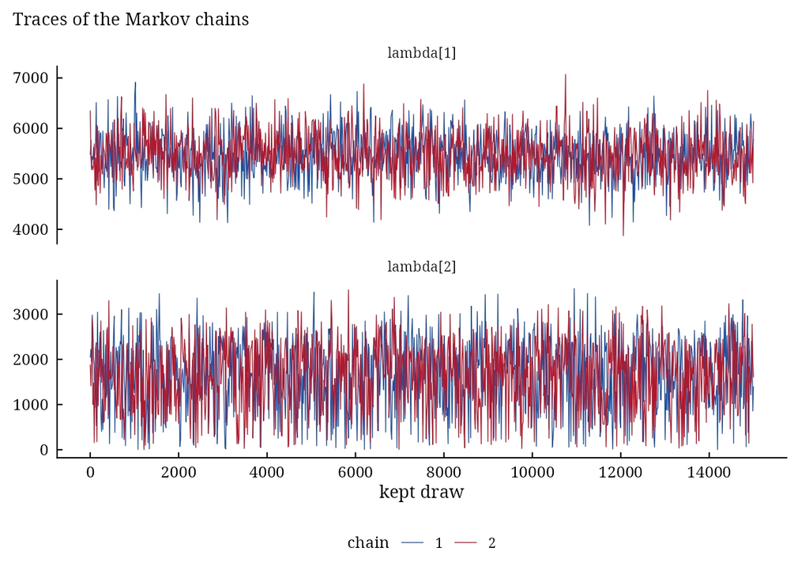

```r
plot(x = fit, which = "trace", pars = c("lambda[1]", "lambda[2]"))
```

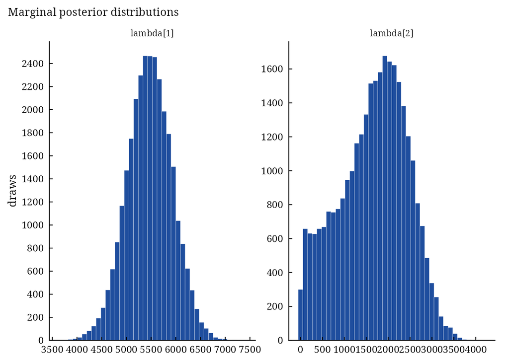

```r
plot(x = fit, which = "density", pars = c("lambda[1]", "lambda[2]"))
```

# 7 Figures 2 to 4: biplots

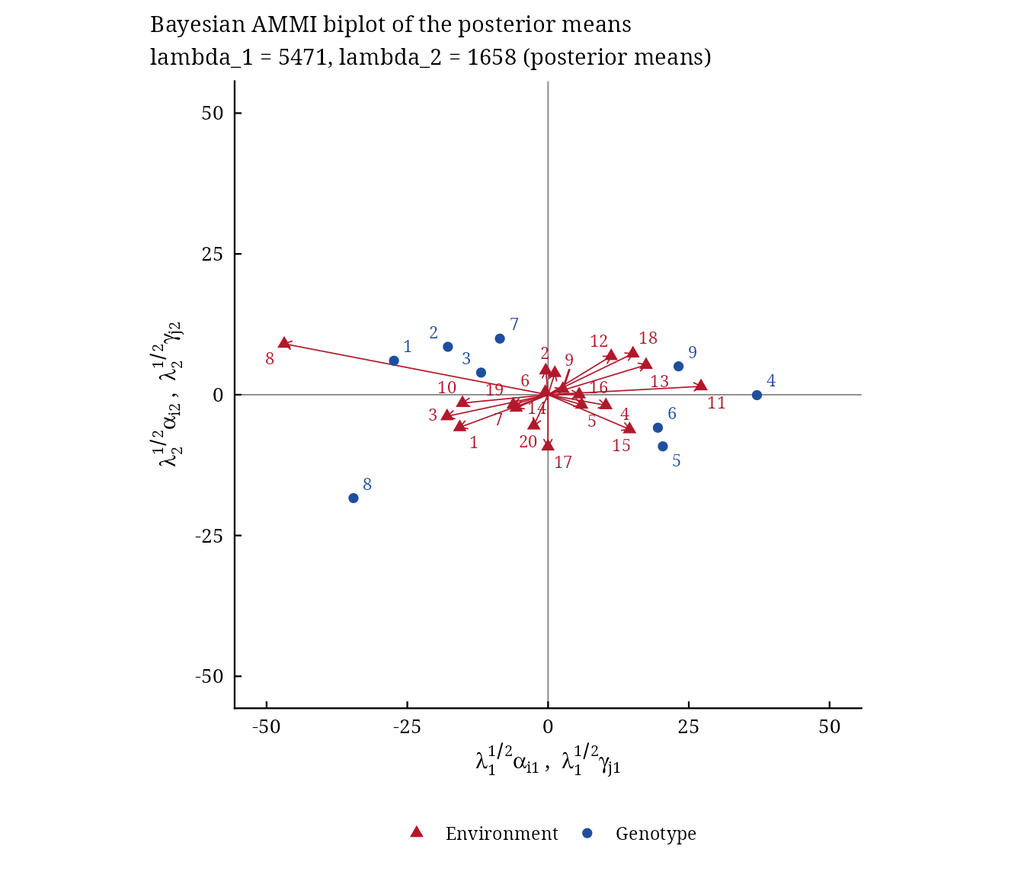

```r
plot(x = fit, which = "biplot")
```

The coordinates are $\lambda_k^{1/2}\alpha_{ik}$ and $\lambda_k^{1/2}\gamma_{jk}$, as the paper defines them. The axes of its figures run from -1 to 1, so they show a rescaled version; the relative positions are the same.

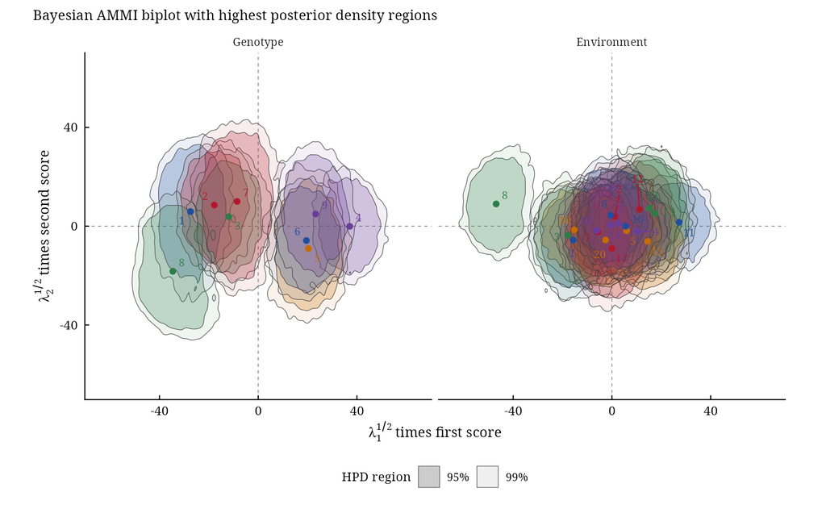

```r
bp <-
  biplots(
      model         = fit
    , burnin        = 0
    , thin          = 0.25
    , pb            = c(0.05, 0.01)
    , plot_stable   = TRUE
    , plot_unstable = TRUE
    , ncolors       = 5
    , .which        = "both"
    , .grid         = 100
    )
bp$biplot
```

```r
bp$biplot_data[axis1_significant == TRUE, list(byplot, name, x, axis1_lower, axis1_upper, group)]
```

```
         byplot   name         x axis1_lower axis1_upper    group
         <char> <char>     <num>       <num>       <num>   <char>
 1:    Genotype      1 -27.40119  -39.009787 -17.0056562 negative
 2:    Genotype      2 -17.78439  -28.769313  -6.9059935 negative
 3:    Genotype      3 -11.92951  -22.387334  -0.5460779 negative
 4:    Genotype      4  37.11681   26.547850  46.4285760 positive
 5:    Genotype      5  20.33477    8.388511  30.8259011 positive
 6:    Genotype      6  19.51037    9.088838  30.3996106 positive
 7:    Genotype      8 -34.57251  -46.037088 -22.9895206 negative
 8:    Genotype      9  23.26336   11.850401  33.6434950 positive
 9: Environment      1 -15.64906  -26.568920  -4.8800356 negative
10: Environment      3 -17.92078  -28.906052  -7.3859744 negative
11: Environment      8 -46.91103  -56.836455 -37.1519907 negative
12: Environment     10 -15.26108  -25.257391  -4.2795139 negative
13: Environment     11  27.22102   16.825997  37.3800310 positive
14: Environment     13  17.43228    6.882893  28.7666430 positive
15: Environment     15  14.44714    3.701040  25.1896927 positive
16: Environment     18  15.08558    3.669220  25.8574122 positive
```

On the first term, genotypes 4, 5, 6 and 9 form a positive group and genotypes 1 and 8 a negative group, as in the paper’s Figure 3. Sites S8 (negative) and S11, S13 and S18 (positive) stand out, as in its Figure 4. With the intervals of Table B1, genotypes 2 and 3 and some further sites also exclude zero at 95%; the paper’s figures show a subset of them.

# 8 References

Crossa, J., Perez-Elizalde, S., Jarquin, D., Cotes, J. M., Viele, K., Liu, G. and Cornelius, P. L. (2011). Bayesian estimation of the additive main effects and multiplicative interaction model. *Crop Science*, 51(4), 1458–1469. doi:10.2135/cropsci2010.06.0343